# X Variables

Week 11

Rex Sitti

Old Dominion University

## Learning Objectives

By the end of this module, you should be able to:

1. Estimate distributed lag and ARDL models with exogenous variables
2. Recognize and avoid spurious regression in non-stationary data
3. Test for cointegration between economic time series
4. Estimate and interpret error correction models (ECM)
5. Forecast using models with exogenous predictors

## Topics

- Distributed Lag Models
- Spurious Regression
- Cointegration
- Error Correction Models

## Motivating Question

Can we use **today’s** information to predict **tomorrow’s** outcomes?

Examples:

- Yield curve → Future GDP growth
- Leading indicators → Recessions
- Diagnoses → Deaths (with lag)

**Challenge**: Both $X$ and $Y$ might be non-stationary!

## GDP and the Yield Curve

[interactive chart not shown]

## GDP and the Yield Curve

```r
# Load or generate GDP and yield curve data
# If you have the real data, use: tmp <- read.csv("../data/fredgraph (2).csv")
# Otherwise, use synthetic data:
tmp <- generate_gdp_yield_data()

colnames(tmp) <- c("DATE", "gdp_pc", "ir3m", "ir10y", "gdp")
rbind(head(tmp, 5), tail(tmp, 5))
```

```
          DATE   gdp_pc     ir3m    ir10y         gdp
1   1962-01-01 1.854027 4.855181 6.886936    10187.13
2   1962-04-01 2.076588 4.567429 6.173610    10400.89
3   1962-07-01 2.878780 5.080138 7.061360    10704.66
4   1962-10-01 2.364549 4.957789 6.373456    10960.79
5   1963-01-01 2.461872 4.750869 6.462766    11233.98
209 2014-01-01 6.097603 7.552940 8.834437 14669250.76
210 2014-04-01 5.435936 7.600835 8.712243 15488733.32
211 2014-07-01 5.513240 7.992515 9.416990 16366642.69
212 2014-10-01 5.558852 7.786975 9.410898 17302202.47
213 2015-01-01 5.938494 7.661873 9.134589 18360814.37
```

## Data Preparation

Once you have your data, you might need to add/modify variables.

- Do this *before* converting to a `ts()` object.

```r
# Create term spread: 10-year minus 3-month rate
tmp$spread <- tmp$ir10y - tmp$ir3m
```

## Data Preparation

You can also modify after creating `ts()` object:

```r
# Convert to quarterly time series starting 1962Q1
tmp <- ts(tmp, start = c(1962, 1), frequency = 4)

# Add spread using ts.union (keeps all columns)
tmp <- ts.union(tmp, spread = tmp[,"ir10y"] - tmp[,"ir3m"], dframe = FALSE)
rbind(head(tmp, 3), tail(tmp, 3))

# Clean up column names
colnames(tmp) <- gsub("tmp.", "", colnames(tmp))
```

```
     tmp.DATE tmp.gdp_pc tmp.ir3m tmp.ir10y     tmp.gdp tmp.spread   spread
[1,]    -2922   1.854027 4.855181  6.886936    10187.13   2.031755 2.031755
[2,]    -2832   2.076588 4.567429  6.173610    10400.89   1.606182 1.606182
[3,]    -2741   2.878780 5.080138  7.061360    10704.66   1.981222 1.981222
[4,]    16252   5.513240 7.992515  9.416990 16366642.69   1.424475 1.424475
[5,]    16344   5.558852 7.786975  9.410898 17302202.47   1.623923 1.623923
[6,]    16436   5.938494 7.661873  9.134589 18360814.37   1.472716 1.472716
```

## Data Manipulation Examples

Creating differences, growth rates, and lags:

```r
# ts.union combines time series, aligning by time
head(ts.union(y = tmp[,"gdp_pc"],
              diff_y = diff(tmp[,"gdp"]),              # First difference
              pc_y = 100*diff(tmp[,"gdp"])/tmp[,"gdp"] # % change
              ), 10)
```

```
               y   diff_y     pc_y
1962 Q1 1.854027       NA       NA
1962 Q2 2.076588 213.7565 2.055176
1962 Q3 2.878780 303.7702 2.837738
1962 Q4 2.364549 256.1331 2.336812
1963 Q1 2.461872 273.1897 2.431815
1963 Q2 3.161289 360.8118 3.111843
1963 Q3 2.714775 319.0842 2.678257
1963 Q4 2.068560 249.0124 2.047312
1964 Q1 2.332311 287.0103 2.305322
1964 Q2 2.449094 308.6742 2.419347
```

## GDP and the Yield Curve

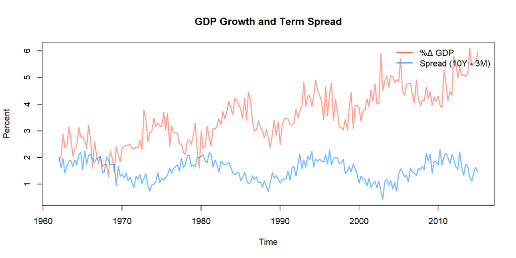

```r
plot(tmp[,c("gdp_pc")], ylim = range(tmp[,c("gdp_pc", "spread")]),
     col = alpha("tomato", .6), lwd = 2,
     ylab = "Percent", main = "GDP Growth and Term Spread")
lines(tmp[,"spread"], col = alpha("dodgerblue", .6), lwd = 2)
abline(h = 0)
legend("topright", lty = 1, col = c("tomato", "dodgerblue"),
       legend = c("%Δ GDP", "Spread (10Y - 3M)"), bty = "n", lwd = 2)
```

## Stationarity Check

Always test for stationarity before modeling:

```r
adf.test(tmp[,"gdp_pc"])
adf.test(tmp[,"spread"])
```

```
    Augmented Dickey-Fuller Test

data:  tmp[, "gdp_pc"]
Dickey-Fuller = -3.074, Lag order = 5, p-value = 0.1256
alternative hypothesis: stationary


    Augmented Dickey-Fuller Test

data:  tmp[, "spread"]
Dickey-Fuller = -2.035, Lag order = 5, p-value = 0.5613
alternative hypothesis: stationary
```

- ACF
- PACF

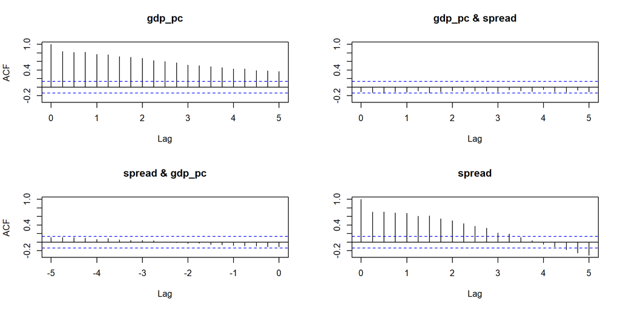

```r
acf(tmp[,c("gdp_pc", "spread")])
```

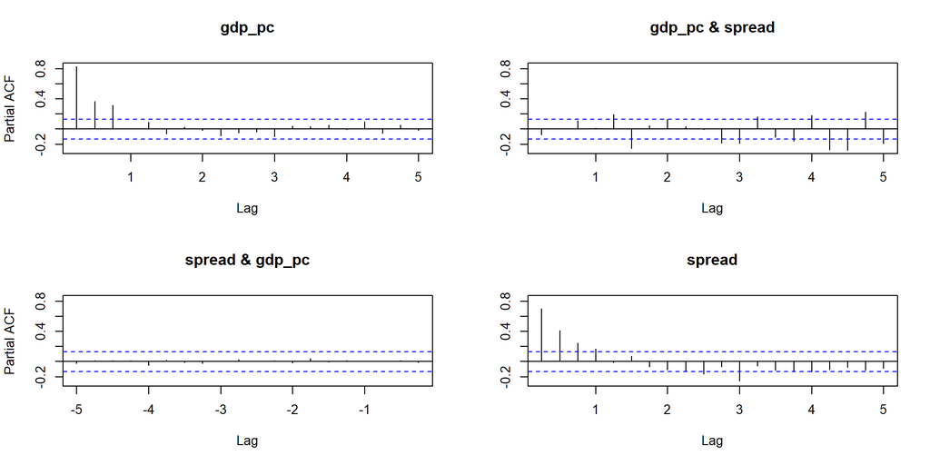

```r
pacf(tmp[,c("gdp_pc", "spread")])
```

# Spurious Regression: The Danger

## What is Spurious Regression?

When two **unrelated** non-stationary series appear to be significantly related.

**The Problem**: Standard t-tests and R² are misleading!

```r
# Simulate two INDEPENDENT random walks
set.seed(123)
N <- 100
y <- cumsum(rnorm(N))  # Random walk 1
x <- cumsum(rnorm(N))  # Random walk 2 (unrelated!)
```

## Spurious Regression: Visualization

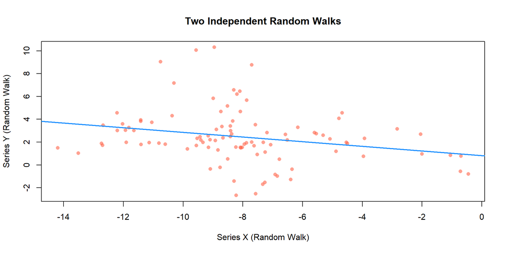

```r
plot(x, y, pch = 16, col = alpha("tomato", 0.6),
     main = "Two Independent Random Walks",
     xlab = "Series X (Random Walk)", ylab = "Series Y (Random Walk)")
abline(lm(y ~ x), col = "dodgerblue", lwd = 2)
text(0, max(y),
     paste0("R² = ", round(summary(lm(y ~ x))$r.squared, 3),
            "\np-value < 0.001"),
     pos = 4, col = "dodgerblue")
```

## Spurious Regression: Monte Carlo

How often do we falsely reject H₀ when there’s **no relationship**?

```r
simulate_regression <- function(N, stationary = TRUE) {
  if(stationary) {
    x <- rnorm(N)
    y <- rnorm(N)
  } else {
    x <- cumsum(rnorm(N))  # Random walk
    y <- cumsum(rnorm(N))  # Random walk
  }
  summary(lm(y ~ x))$coefficients[2, 4] < 0.05  # Reject at 5%?
}

set.seed(456)
nsim <- 1000
```

## Spurious Regression: Results

```r
# False positive rates
stationary_rejects <- mean(replicate(nsim, simulate_regression(100, TRUE)))
rw_rejects <- mean(replicate(nsim, simulate_regression(100, FALSE)))
```

| Data Type | False Positive Rate | Expected |
| --- | --- | --- |
| Stationary (I(0)) | 4.1% | 5% ✓ |
| Random Walk (I(1)) | 77% | 5% ✗ |

**With I(1) data, we find “significant” relationships ~75% of the time even when there’s none!**

## Detecting Spurious Regression

**Warning signs:**

1. High R² but low Durbin-Watson statistic (DW < 1)
2. Non-stationary residuals (fail ADF test)
3. Economic theory suggests no relationship

**Solution**: Test residuals for stationarity!

```r
spurious_reg <- lm(y ~ x)
adf.test(spurious_reg$residuals)  # Should reject if cointegrated
```

## Three Solutions to Spurious Regression

1. **First Differences** (if not cointegrated)
   - Model: $\Delta Y_t = \alpha + \beta \Delta X_t + e_t$
   - Loses long-run information
2. **Cointegration + ECM** (if cointegrated)
   - Captures both short-run and long-run relationships
   - We’ll cover this next!
3. **Detrending**
   - Remove common trends first
   - Less common in modern practice

# Distributed Lag Models

## Two Main R Packages

`dynlm`, `dynlm()`

- Data can be a `ts()` object
- Lags: `L(var, i:j)` more intuitive
- No built-in prediction method
- Works with `stargazer`

`dLagM`, `ardlDlm()`

- Data must be a `data.frame`
- Lags: `p` and `q` less intuitive
- Has `forecast()` method
- Doesn’t work well with `stargazer`

```r
library("dynlm")
library("dLagM")
```

# `dynlm`

## Using dynlm()

Main model: `dynlm()`

- Create lags with `L()` function
  - `L(var, i:j)` where `i:j` is lag vector
  - Can use any vector: `0:4`, `c(1,4,8)`, etc.

Example structures:

- `L(spread, 0)` = current value
- `L(spread, 1)` = one lag
- `L(spread, 0:4)` = current through 4 lags

## Simple vs Distributed Lag

```r
# Static model (no lags)
r1 <- dynlm(gdp_pc ~ spread, tmp)

# Distributed lag model (current + 1 lag)
r2 <- dynlm(gdp_pc ~ L(spread, 0:1), tmp)

stargazer::stargazer(r1, r2, type = "html",
                     column.labels = c("Static", "DL(1)"))
```

|  | *Dependent variable:* |  |
| --- | --- | --- |
|  | gdp_pc |  |
|  | Static | DL(1) |
|  | (1) | (2) |
| spread | -0.287 |  |
|  | (0.181) |  |
| L(spread, 0:1)0 |  | -0.076 |
|  |  | (0.257) |
| L(spread, 0:1)1 |  | -0.262 |
|  |  | (0.256) |
| Constant | 3.971*** | 4.059*** |
|  | (0.288) | (0.310) |
| Observations | 213 | 212 |
| R<sup>2</sup> | 0.012 | 0.015 |
| Adjusted R<sup>2</sup> | 0.007 | 0.005 |
| Residual Std. Error | 1.020 (df = 211) | 1.017 (df = 209) |
| F Statistic | 2.510 (df = 1; 211) | 1.578 (df = 2; 209) |
| *Note:* | *p<0.1; **p<0.05;*** p<0.01 |  |

## Alternative Lag Specifications

These three are equivalent:

```r
r1 <- dynlm(gdp_pc ~ spread + L(spread, 1), tmp)  # Explicit
r2 <- dynlm(gdp_pc ~ L(spread, 0:1), tmp)         # Compact
r3 <- dynlm(gdp_pc ~ L(spread, 0:1), tmp)         # Same

stargazer::stargazer(r1, r2, r3, type = "html")
```

|  | *Dependent variable:* |  |  |
| --- | --- | --- | --- |
|  | gdp_pc |  |  |
|  | (1) | (2) | (3) |
| spread | -0.076 |  |  |
|  | (0.257) |  |  |
| L(spread, 1) | -0.262 |  |  |
|  | (0.256) |  |  |
| L(spread, 0:1)0 |  | -0.076 | -0.076 |
|  |  | (0.257) | (0.257) |
| L(spread, 0:1)1 |  | -0.262 | -0.262 |
|  |  | (0.256) | (0.256) |
| Constant | 4.059*** | 4.059*** | 4.059*** |
|  | (0.310) | (0.310) | (0.310) |
| Observations | 212 | 212 | 212 |
| R<sup>2</sup> | 0.015 | 0.015 | 0.015 |
| Adjusted R<sup>2</sup> | 0.005 | 0.005 | 0.005 |
| Residual Std. Error (df = 209) | 1.017 | 1.017 | 1.017 |
| F Statistic (df = 2; 209) | 1.578 | 1.578 | 1.578 |
| *Note:* | *p<0.1; **p<0.05;*** p<0.01 |  |  |

## Choosing Lag Length

Use information criteria (AIC) to select optimal lags:

```r
r1 <- dynlm(gdp_pc ~ L(spread, 0), tmp)
r2 <- dynlm(gdp_pc ~ L(spread, 0:4), tmp)
r3 <- dynlm(gdp_pc ~ L(spread, 0:8), tmp)

stargazer::stargazer(r1, r2, r3,
                     add.lines = list(c("AIC",
                                        round(AIC(r1), 2),
                                        round(AIC(r2), 2),
                                        round(AIC(r3), 2))),
                     column.labels = c("DL(0)", "DL(4)", "DL(8)"),
                     omit.stat = c("ser", "f"),
                     type = "html")
```

|  | *Dependent variable:* |  |  |
| --- | --- | --- | --- |
|  | gdp_pc |  |  |
|  | DL(0) | DL(4) | DL(8) |
|  | (1) | (2) | (3) |
| L(spread, 0) | -0.287 |  |  |
|  | (0.181) |  |  |
| L(spread, 0:4)0 |  | -0.001 |  |
|  |  | (0.301) |  |
| L(spread, 0:4)1 |  | -0.072 |  |
|  |  | (0.307) |  |
| L(spread, 0:4)2 |  | -0.144 |  |
|  |  | (0.309) |  |
| L(spread, 0:4)3 |  | -0.009 |  |
|  |  | (0.305) |  |
| L(spread, 0:4)4 |  | -0.140 |  |
|  |  | (0.299) |  |
| L(spread, 0:8)0 |  |  | 0.032 |
|  |  |  | (0.308) |
| L(spread, 0:8)1 |  |  | -0.083 |
|  |  |  | (0.318) |
| L(spread, 0:8)2 |  |  | -0.091 |
|  |  |  | (0.327) |
| L(spread, 0:8)3 |  |  | 0.009 |
|  |  |  | (0.331) |
| L(spread, 0:8)4 |  |  | -0.084 |
|  |  |  | (0.338) |
| L(spread, 0:8)5 |  |  | 0.174 |
|  |  |  | (0.332) |
| L(spread, 0:8)6 |  |  | -0.282 |
|  |  |  | (0.328) |
| L(spread, 0:8)7 |  |  | -0.089 |
|  |  |  | (0.318) |
| L(spread, 0:8)8 |  |  | 0.059 |
|  |  |  | (0.308) |
| Constant | 3.971*** | 4.116*** | 4.119*** |
|  | (0.288) | (0.329) | (0.348) |
| AIC | 617.04 | 610.17 | 605.97 |
| Observations | 213 | 209 | 205 |
| R<sup>2</sup> | 0.012 | 0.016 | 0.019 |
| Adjusted R<sup>2</sup> | 0.007 | -0.008 | -0.027 |
| *Note:* | *p<0.1; **p<0.05;*** p<0.01 |  |  |

Lower AIC is better. Here DL(4) or DL(8) preferred.

## Aligning Sample Sizes

When comparing models with different lags, ensure same sample:

```r
# All models should use same time period for fair comparison
r1 <- dynlm(gdp_pc ~ L(spread, 0),
            ts(tmp[9:212,], end = c(2014, 4), frequency = 4))
r2 <- dynlm(gdp_pc ~ L(spread, 0:4),
            ts(tmp[5:212,], end = c(2014, 4), frequency = 4))
r3 <- dynlm(gdp_pc ~ L(spread, 0:8), tmp)

stargazer::stargazer(r1, r2, r3,
                     add.lines = list(c("AIC",
                                        round(AIC(r1), 2),
                                        round(AIC(r2), 2),
                                        round(AIC(r3), 2))),
                     omit.stat = c("ser", "f"),
                     type = "html")
```

|  | *Dependent variable:* |  |  |
| --- | --- | --- | --- |
|  | gdp_pc |  |  |
|  | (1) | (2) | (3) |
| L(spread, 0) | -0.228 |  |  |
|  | (0.180) |  |  |
| L(spread, 0:4)0 |  | -0.004 |  |
|  |  | (0.299) |  |
| L(spread, 0:4)1 |  | -0.126 |  |
|  |  | (0.308) |  |
| L(spread, 0:4)2 |  | -0.114 |  |
|  |  | (0.310) |  |
| L(spread, 0:4)3 |  | 0.036 |  |
|  |  | (0.308) |  |
| L(spread, 0:4)4 |  | -0.114 |  |
|  |  | (0.301) |  |
| L(spread, 0:8)0 |  |  | 0.032 |
|  |  |  | (0.308) |
| L(spread, 0:8)1 |  |  | -0.083 |
|  |  |  | (0.318) |
| L(spread, 0:8)2 |  |  | -0.091 |
|  |  |  | (0.327) |
| L(spread, 0:8)3 |  |  | 0.009 |
|  |  |  | (0.331) |
| L(spread, 0:8)4 |  |  | -0.084 |
|  |  |  | (0.338) |
| L(spread, 0:8)5 |  |  | 0.174 |
|  |  |  | (0.332) |
| L(spread, 0:8)6 |  |  | -0.282 |
|  |  |  | (0.328) |
| L(spread, 0:8)7 |  |  | -0.089 |
|  |  |  | (0.318) |
| L(spread, 0:8)8 |  |  | 0.059 |
|  |  |  | (0.308) |
| Constant | 3.909*** | 4.054*** | 4.119*** |
|  | (0.286) | (0.327) | (0.348) |
| AIC | 584.85 | 591.79 | 605.97 |
| Observations | 204 | 204 | 205 |
| R<sup>2</sup> | 0.008 | 0.013 | 0.019 |
| Adjusted R<sup>2</sup> | 0.003 | -0.012 | -0.027 |
| *Note:* | *p<0.1; **p<0.05;*** p<0.01 |  |  |

## ARDL Models

Autoregressive Distributed Lag: includes lags of both Y and X

```r
r1 <- dynlm(gdp_pc ~ L(gdp_pc, 1:2), tmp)                    # AR(2)
r2 <- dynlm(gdp_pc ~ L(spread, 0:2), tmp)                    # DL(2)
r3 <- dynlm(gdp_pc ~ L(gdp_pc, 1:2) + L(spread, 0:2), tmp)  # ARDL(2,2)

stargazer::stargazer(r1, r2, r3,
                     add.lines = list(c("AIC",
                                        round(AIC(r1), 2),
                                        round(AIC(r2), 2),
                                        round(AIC(r3), 2))),
                     column.labels = c("AR(2)", "DL(2)", "ARDL(2,2)"),
                     omit.stat = c("ser", "f"),
                     type = "html")
```

|  | *Dependent variable:* |  |  |
| --- | --- | --- | --- |
|  | gdp_pc |  |  |
|  | AR(2) | DL(2) | ARDL(2,2) |
|  | (1) | (2) | (3) |
| L(gdp_pc, 1:2)1 | 0.498*** |  | 0.498*** |
|  | (0.063) |  | (0.064) |
| L(gdp_pc, 1:2)2 | 0.425*** |  | 0.422*** |
|  | (0.063) |  | (0.064) |
| L(spread, 0:2)0 |  | -0.016 | 0.037 |
|  |  | (0.283) | (0.137) |
| L(spread, 0:2)1 |  | -0.141 | -0.068 |
|  |  | (0.283) | (0.137) |
| L(spread, 0:2)2 |  | -0.202 | -0.009 |
|  |  | (0.282) | (0.137) |
| Constant | 0.299** | 4.096*** | 0.366* |
|  | (0.127) | (0.318) | (0.210) |
| AIC | 301.68 | 611.66 | 307.3 |
| Observations | 211 | 211 | 211 |
| R<sup>2</sup> | 0.771 | 0.016 | 0.772 |
| Adjusted R<sup>2</sup> | 0.769 | 0.002 | 0.766 |
| *Note:* | *p<0.1; **p<0.05;*** p<0.01 |  |  |

# `dLagM`

## Using ardlDlm()

Main function: `ardlDlm()`

- `p` = lags of X variables
- `q` = lags of Y variable
- `remove` = list to exclude specific lags

Example: ARDL(2,2) with some lags removed

```r
rmv <- list(
  p = list(spread = c(0, 1)),  # Remove spread₀ and spread₁
  q = c(1)                       # Remove Y₁
)
```

## DL(2) Model

Distributed lag with 2 lags of spread, no Y lags:

```r
rmv.q <- c(1)                    # Remove Y₁ (keeps only Y₂)
rmv.p <- list(spread = c())      # Keep all spread lags
rmv <- list(p = rmv.p, q = rmv.q)

r1 <- ardlDlm(formula = gdp_pc ~ spread,
              data = as.data.frame(tmp),
              p = 2,   # 2 lags of X (spread₀, spread₁, spread₂)
              q = 1,   # 1 lag of Y (but we remove it)
              remove = rmv)
summary(r1)
```

```
Time series regression with "ts" data:
Start = 3, End = 213

Call:
dynlm(formula = as.formula(model.text), data = data)

Residuals:
    Min      1Q  Median      3Q     Max
-2.2082 -0.7580 -0.1521  0.7537  2.6121

Coefficients:
            Estimate Std. Error t value Pr(>|t|)
(Intercept)  4.09601    0.31816  12.874   <2e-16 ***
spread.t    -0.01588    0.28323  -0.056    0.955
spread.1    -0.14089    0.28260  -0.499    0.619
spread.2    -0.20180    0.28161  -0.717    0.474
---
Signif. codes:  0 '***' 0.001 '**' 0.01 '*' 0.05 '.' 0.1 ' ' 1

Residual standard error: 1.016 on 207 degrees of freedom
Multiple R-squared:  0.01585,   Adjusted R-squared:  0.001587
F-statistic: 1.111 on 3 and 207 DF,  p-value: 0.3455
```

## AR(2) Model

```r
rmv.q <- c()                    # Keep Y lags
rmv.p <- list(spread = c(1))    # Remove spread₁
rmv <- list(p = rmv.p, q = rmv.q)

r2 <- ardlDlm(formula = gdp_pc ~ spread,
              data = as.data.frame(tmp),
              p = 1,   # 1 lag of X (but remove it)
              q = 2,   # 2 lags of Y (Y₁, Y₂)
              remove = rmv)
summary(r2)
```

```
Time series regression with "ts" data:
Start = 3, End = 213

Call:
dynlm(formula = as.formula(model.text), data = data)

Residuals:
     Min       1Q   Median       3Q      Max
-1.37259 -0.26337 -0.05148  0.26359  1.88101

Coefficients:
            Estimate Std. Error t value Pr(>|t|)
(Intercept)  0.32809    0.19537   1.679   0.0946 .
spread.t    -0.01752    0.08781  -0.200   0.8420
gdp_pc.1     0.49700    0.06334   7.846 2.26e-13 ***
gdp_pc.2     0.42489    0.06345   6.697 1.97e-10 ***
---
Signif. codes:  0 '***' 0.001 '**' 0.01 '*' 0.05 '.' 0.1 ' ' 1

Residual standard error: 0.4899 on 207 degrees of freedom
Multiple R-squared:  0.7714,    Adjusted R-squared:  0.7681
F-statistic: 232.8 on 3 and 207 DF,  p-value: < 2.2e-16
```

## ARDL(2,2) Full Model

Both Y and X lags included:

```r
rmv.q <- c()                    # Keep all Y lags
rmv.p <- list(spread = c())     # Keep all spread lags
rmv <- list(p = rmv.p, q = rmv.q)

r3 <- ardlDlm(formula = gdp_pc ~ spread,
              data = as.data.frame(tmp),
              p = 2,   # Spread: current + 2 lags
              q = 2,   # GDP: 2 lags
              remove = rmv)
summary(r3)
```

```
Time series regression with "ts" data:
Start = 3, End = 213

Call:
dynlm(formula = as.formula(model.text), data = data)

Residuals:
     Min       1Q   Median       3Q      Max
-1.34945 -0.26919 -0.05875  0.27046  1.89104

Coefficients:
             Estimate Std. Error t value Pr(>|t|)
(Intercept)  0.366430   0.210218   1.743   0.0828 .
spread.t     0.036762   0.137202   0.268   0.7890
spread.1    -0.067712   0.137061  -0.494   0.6218
spread.2    -0.008925   0.136532  -0.065   0.9479
gdp_pc.1     0.498294   0.063712   7.821 2.72e-13 ***
gdp_pc.2     0.422488   0.063854   6.617 3.14e-10 ***
---
Signif. codes:  0 '***' 0.001 '**' 0.01 '*' 0.05 '.' 0.1 ' ' 1

Residual standard error: 0.4919 on 205 degrees of freedom
Multiple R-squared:  0.7718,    Adjusted R-squared:  0.7662
F-statistic: 138.6 on 5 and 205 DF,  p-value: < 2.2e-16
```

## ARDL(2,2) Restricted

Custom lag structure:

```r
rmv.q <- c(1)                         # Remove Y₁ (keep Y₂)
rmv.p <- list(spread = c(0,1))        # Remove spread₀, spread₁ (keep spread₂)
rmv <- list(p = rmv.p, q = rmv.q)

r4 <- ardlDlm(formula = gdp_pc ~ spread,
              data = as.data.frame(tmp),
              p = 2,
              q = 2,
              remove = rmv)
summary(r4)
```

```
Time series regression with "ts" data:
Start = 3, End = 213

Call:
dynlm(formula = as.formula(model.text), data = data)

Residuals:
     Min       1Q   Median       3Q      Max
-1.75108 -0.33262  0.01955  0.31748  1.87886

Coefficients:
            Estimate Std. Error t value Pr(>|t|)
(Intercept)  0.68632    0.21848   3.141  0.00193 **
spread.2    -0.07006    0.09940  -0.705  0.48171
gdp_pc.2     0.84536    0.03843  21.996  < 2e-16 ***
---
Signif. codes:  0 '***' 0.001 '**' 0.01 '*' 0.05 '.' 0.1 ' ' 1

Residual standard error: 0.5565 on 208 degrees of freedom
Multiple R-squared:  0.7036,    Adjusted R-squared:  0.7008
F-statistic: 246.9 on 2 and 208 DF,  p-value: < 2.2e-16
```

Model: $\text{GDP}_t = \alpha + \beta_2 \text{GDP}_{t-2} + \gamma_2 \text{Spread}_{t-2} + e_t$

## Granger Causality

Granger Causality: when lags of $X$ predict future values of $Y$

**Critical distinction:**

- Granger Causality $\neq$ (Causal) Effect
- It means: $X$ today predicts $Y$ tomorrow
- Likely direction: Future GDP expectations → Today’s spread
  - GDP causes Spread
  - Spread “Granger causes” GDP (predicts it)

## Testing Granger Causality

```r
# Test if spread Granger-causes GDP growth
lmtest::grangertest(gdp_pc ~ spread, tmp, order = 1)
lmtest::grangertest(gdp_pc ~ spread, tmp, order = 2)
```

```
Granger causality test

Model 1: gdp_pc ~ Lags(gdp_pc, 1:1) + Lags(spread, 1:1)
Model 2: gdp_pc ~ Lags(gdp_pc, 1:1)
  Res.Df Df      F Pr(>F)
1    209
2    210 -1 0.6227 0.4309
Granger causality test

Model 1: gdp_pc ~ Lags(gdp_pc, 1:2) + Lags(spread, 1:2)
Model 2: gdp_pc ~ Lags(gdp_pc, 1:2)
  Res.Df Df    F Pr(>F)
1    206
2    208 -2 0.15 0.8608
```

# Forecasting with X

## Forecasting Setup

To forecast Y, we need:

1. Fitted ARDL model
2. **Future values of X** (forecasts or assumptions)
3. Forecast horizon h

```r
forecast(model,
         x,              # Future X values (X_{t+1}, ..., X_{t+h})
         h = 1,          # Forecast horizon
         interval = FALSE,
         level = 0.95)
```

## Forecasting Strategy

**Goal**: Forecast 2013-2014 GDP growth

**Our approach:**

$$\begin{align}
\%\Delta \text{GDP}_t &= \alpha + \sum_{i=1}^{2}\beta_i \%\Delta \text{GDP}_{t-i} + \gamma\text{Spread}_{t-2} + e_t \\
\text{Spread}_t &\sim \text{ARIMA}(p,d,q)
\end{align}$$

**Steps:**

1. Fit ARDL model for GDP
2. Fit ARIMA model for Spread
3. Forecast Spread first, then use in GDP forecast

## Step 1: Fit GDP Model

```r
# Create holdout indicator (1 = test period)
c_namez <- colnames(tmp)
tmp <- ts.union(tmp, h = ifelse(time(tmp) >= 2013, 1, 0))
colnames(tmp) <- c(c_namez, "h")
lim <- tmp[,"h"] == 0  # Training data

# Fit ARDL model on training data
rmv.q <- c()
rmv.p <- list(spread = c(0,1))
rmv <- list(p = rmv.p, q = rmv.q)

main <- ardlDlm(formula = gdp_pc ~ spread,
                data = as.data.frame(tmp[lim,]),
                p = 2, q = 2, remove = rmv)
```

## Step 1: Results

```r
summary(main)
```

```
Time series regression with "ts" data:
Start = 3, End = 204

Call:
dynlm(formula = as.formula(model.text), data = data)

Residuals:
     Min       1Q   Median       3Q      Max
-1.36025 -0.27156 -0.05816  0.27428  1.88979

Coefficients:
            Estimate Std. Error t value Pr(>|t|)
(Intercept)  0.42792    0.20693   2.068   0.0399 *
spread.2    -0.04005    0.08942  -0.448   0.6547
gdp_pc.1     0.48432    0.06501   7.450 2.83e-12 ***
gdp_pc.2     0.41594    0.06485   6.414 1.02e-09 ***
---
Signif. codes:  0 '***' 0.001 '**' 0.01 '*' 0.05 '.' 0.1 ' ' 1

Residual standard error: 0.4924 on 198 degrees of freedom
Multiple R-squared:  0.7368,    Adjusted R-squared:  0.7328
F-statistic: 184.7 on 3 and 198 DF,  p-value: < 2.2e-16
```

## Step 2: Forecast Spread

```r
# Fit ARIMA to spread
sub <- auto.arima(tmp[lim,"spread"])
summary(sub)
```

```
Series: tmp[lim, "spread"]
ARIMA(2,0,1) with non-zero mean

Coefficients:
         ar1     ar2      ma1    mean
      0.7576  0.1916  -0.4914  1.6014
s.e.  0.1051  0.0956   0.0871  0.1521

sigma^2 = 0.05674:  log likelihood = 4.54
AIC=0.92   AICc=1.23   BIC=17.51

Training set error measures:
                       ME     RMSE       MAE       MPE     MAPE      MASE
Training set -0.004550993 0.235852 0.1880149 -3.341441 13.64688 0.7944315
                     ACF1
Training set -0.007307681
```

## Step 2: Spread Forecasts

[figure not shown]

```r
# Generate spread forecasts
p <- predict(sub, n.ahead = 8)

# Get actual test period data (first 8 quarters of test set)
test_spread <- tmp[!lim,"spread"][1:8]
test_times <- time(tmp[!lim,])[1:8]

plot(tmp[,"spread"], lwd = 1,
     ylim = c(-1, 4), xlim = c(2000, 2015),
     xlab = "Quarter", ylab = "Percentage Points",
     main = "Term Spread: Actual vs Forecast")
lines(test_times, test_spread, col = "dodgerblue", lwd = 3)
lines(test_times, p$pred, col = "tomato", lwd = 3)
legend("bottomright", bty = "n", lty = 1, lwd = 2,
       col = c("tomato", "dodgerblue"),
       legend = c("Forecast", "Actual"))
```

## Step 3: GDP Forecasts

[figure not shown]

```r
# Benchmark: ARIMA forecast (no spread info)
r1 <- auto.arima(tmp[lim,"gdp_pc"])
p1 <- predict(r1, n.ahead = 8)

# ARDL forecast using spread forecasts
f <- forecast(model = main, x = p$pred, h = 8, interval = FALSE)

# Get actual test period data (first 8 quarters of test set)
test_gdp <- tmp[!lim,"gdp_pc"][1:8]
test_times <- time(tmp[!lim,])[1:8]

plot(tmp[,"gdp_pc"], ylim = c(-2, 3), xlim = c(2000, 2015),
     xlab = "Quarter", ylab = "Percentage Points",
     main = "GDP Growth: Forecast Comparison")
lines(test_times, test_gdp, col = "dodgerblue", lwd = 3)
lines(test_times, f$forecasts, col = "tomato", lwd = 3)
lines(test_times, as.numeric(p1$pred), col = "mediumseagreen", lwd = 3)
legend("bottomright", bty = "n", lty = 1, lwd = 2,
       col = c("tomato", "mediumseagreen", "dodgerblue"),
       legend = c("ARDL (w/ Spread)", "ARIMA", "Actual"))
```

## Alternative: auto.arima with xreg

`auto.arima` can also use external regressors:

```r
# Create lagged spread variable
c_namez <- colnames(tmp)
tmp <- ts.intersect(tmp, spread_l2 = lag(tmp[,"spread"], -2))
colnames(tmp) <- c(c_namez, "spread_l2")

# Compare models
r1 <- auto.arima(tmp[,"gdp_pc"])                          # No X
r2 <- auto.arima(tmp[,"gdp_pc"], xreg = tmp[,"spread_l2"]) # With X
```

## Results Comparison

```r
r1
```

```
Series: tmp[, "gdp_pc"]
ARIMA(2,1,2)(1,0,0)[4]

Coefficients:
         ar1      ar2      ma1     ma2     sar1
      0.6943  -0.1817  -1.3988  0.6777  -0.1988
s.e.  0.1721   0.1485   0.1660  0.0808   0.1040

sigma^2 = 0.1989:  log likelihood = -126.27
AIC=264.55   AICc=264.96   BIC=284.63
```

```r
r2
```

```
Series: tmp[, "gdp_pc"]
Regression with ARIMA(2,1,2)(1,0,0)[4] errors

Coefficients:
         ar1      ar2      ma1     ma2     sar1     xreg
      0.6829  -0.1909  -1.3858  0.6737  -0.2059  -0.0495
s.e.  0.1704   0.1437   0.1636  0.0843   0.1036   0.1296

sigma^2 = 0.1997:  log likelihood = -126.2
AIC=266.4   AICc=266.96   BIC=289.83
```

# Cointegration

## Motivation: The Random Walk Problem

eco.uc3m.es/~jgonzalo/teaching/econometriaii/cointegration.htm

## What is Cointegration?

Two I(1) series are **cointegrated** if their linear combination is I(0).

**Example**: Consumption and Income

- Both trend upward over time (I(1))
- But their **ratio** stays relatively stable (I(0))
- They share a common stochastic trend
- They move together in the long run

**Key insight**: If cointegrated, there exists a long-run equilibrium relationship!

## Economic Intuition

Consider consumption as a fraction of income:

$$C_t = kY_t$$

Taking logs:

$$\log(C_t) = \log(k) + \log(Y_t)$$

Rearranging:

$$\log(C_t) - \log(Y_t) = \log(k)$$

If C and Y are cointegrated, the difference is stationary (constant on average).

## Testing for Cointegration

**Engle-Granger Two-Step Procedure:**

1. Regress $Y_t = \alpha + \beta X_t + e_t$
2. Test if residuals $\hat{e}_t$ are stationary (ADF test)

**If residuals are I(0)**: Variables are cointegrated ✓

**If residuals are I(1)**: No cointegration, use first differences ✗

## Consumption & Income Example

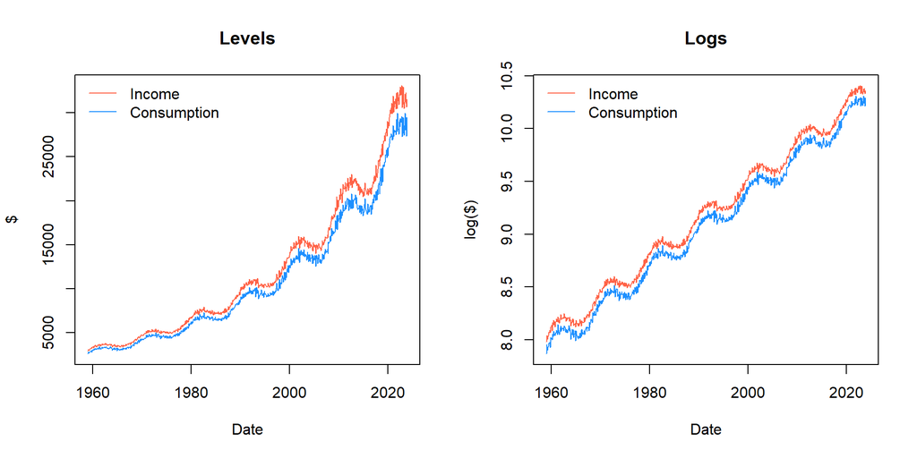

```r
# Load or generate consumption and income data
# If you have real data, use: pi <- read.csv("../data/inc_pce.csv")
# Otherwise, use synthetic data:
pi <- generate_consumption_income_data()
pi$DATE <- ymd(pi$DATE)

par(mfrow = c(1, 2))
# Levels
plot(pi$DATE, pi$PI, type = "l",
     ylim = range(pi$PI, pi$PCE),
     xlab = "Date", ylab = "$",
     main = "Levels",
     col = "tomato")
lines(pi$DATE, pi$PCE, col = "dodgerblue")
legend("topleft", legend = c("Income", "Consumption"),
       col = c("tomato", "dodgerblue"), lty = 1, bty = "n")

# Logs
plot(pi$DATE, log(pi$PI), type = "l",
     ylim = log(range(pi$PI, pi$PCE)),
     xlab = "Date", ylab = "log($)",
     main = "Logs",
     col = "tomato")
lines(pi$DATE, log(pi$PCE), col = "dodgerblue")
legend("topleft", legend = c("Income", "Consumption"),
       col = c("tomato", "dodgerblue"), lty = 1, bty = "n")
```

## Step 1: Estimate Cointegrating Regression

```r
# Long-run relationship in logs
reg <- lm(log(PCE) ~ log(PI), data = pi)
summary(reg)
```

```
Call:
lm(formula = log(PCE) ~ log(PI), data = pi)

Residuals:
      Min        1Q    Median        3Q       Max
-0.041567 -0.009796 -0.000506  0.010182  0.044308

Coefficients:
              Estimate Std. Error t value Pr(>|t|)
(Intercept) -0.1072205  0.0071637  -14.97   <2e-16 ***
log(PI)      1.0003025  0.0007784 1285.03   <2e-16 ***
---
Signif. codes:  0 '***' 0.001 '**' 0.01 '*' 0.05 '.' 0.1 ' ' 1

Residual standard error: 0.01477 on 778 degrees of freedom
Multiple R-squared:  0.9995,    Adjusted R-squared:  0.9995
F-statistic: 1.651e+06 on 1 and 778 DF,  p-value: < 2.2e-16
```

## Step 2: Check Residuals

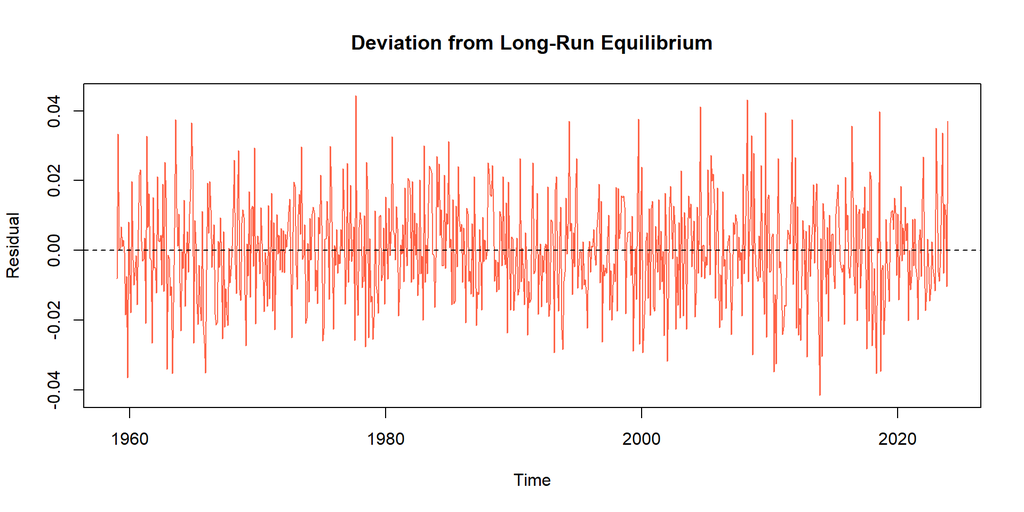

```r
plot(pi$DATE, reg$residuals,
     xlab = "Time", ylab = "Residual",
     main = "Deviation from Long-Run Equilibrium",
     type = "l", col = "tomato")
abline(h = 0, lty = 2)
```

Residuals show mean reversion → suggests cointegration.

## Step 2: Test Residuals for Stationarity

```r
# ADF test on residuals
tseries::adf.test(reg$residuals)
```

```
    Augmented Dickey-Fuller Test

data:  reg$residuals
Dickey-Fuller = -8.6845, Lag order = 9, p-value = 0.01
alternative hypothesis: stationary
```

**p-value = 0.01 → Reject unit root**

Residuals are stationary → Consumption and Income are **cointegrated**!

# Error Correction Models

## From ARDL to ECM

If variables are cointegrated, we can estimate an **Error Correction Model**.

**Starting point**: ARDL(1,1)

$$C_t = \alpha + \beta_1 Y_t + \beta_2 Y_{t-1} + \gamma C_{t-1} + e_t$$

**Long-run equilibrium**: When $C_t = C_{t-1} = C^*$ and $Y_t = Y_{t-1} = Y^*$:

$$C^* = \frac{\alpha + (\beta_1 + \beta_2)Y^*}{1 - \gamma}$$

## Reparameterization to ECM

From ARDL form:

$$C_t = \alpha + \beta_1 Y_t + \beta_2 Y_{t-1} + \gamma C_{t-1} + e_t$$

Subtract $C_{t-1}$ from both sides:

$$\Delta C_t = \alpha + \beta_1 Y_t + \beta_2 Y_{t-1} + (\gamma - 1) C_{t-1} + e_t$$

Add and subtract $\beta_1 Y_{t-1}$:

$$\Delta C_t = \alpha + \beta_1(Y_t - Y_{t-1}) + (\beta_1 + \beta_2)Y_{t-1} + (\gamma - 1)C_{t-1} + e_t$$

Rearrange:

$$\Delta C_t = \alpha + \beta_1 \Delta Y_t + (\gamma - 1)[C_{t-1} - \frac{\beta_1 + \beta_2}{1-\gamma}Y_{t-1}] + e_t$$

## ECM Interpretation

$$\Delta C_t = \beta_1 \Delta Y_t + \delta[C_{t-1} - \theta Y_{t-1}] + \text{constant} + e_t$$

**Two components:**

1. **Short-run dynamics**: $\beta_1 \Delta Y_t$
   - Immediate response to income changes
2. **Error correction**: $\delta[C_{t-1} - \theta Y_{t-1}]$
   - $\delta < 0$: restores equilibrium
   - Larger $|\delta|$ → faster adjustment
   - $C_{t-1} - \theta Y_{t-1}$ = deviation from equilibrium

## Estimating ECM

```r
# Prepare time series data
pi_ts <- ts(pi, start = c(1959, 1), frequency = 12)

# Create differences and error correction term
pi_ts <- ts.intersect(pi_ts,
                      pc = diff(log(pi_ts[,"PCE"])),    # ΔC
                      pi = diff(log(pi_ts[,"PI"])),     # ΔY
                      z = reg$residuals[2:length(reg$residuals)]) # EC term

colnames(pi_ts) <- c("DATE", "PI", "PCE", "pc", "pi", "z")
```

## ECM Specification

```r
# Estimate ECM with dLagM
rmv.q <- c()                              # Keep Y lags
rmv.p <- list(pi = c(),                   # Keep ΔY lags
              z = c(0, 2:12))             # Keep only z₁ (EC term)
rmv <- list(p = rmv.p, q = rmv.q)

ecm <- ardlDlm(formula = pc ~ pi + z,
               data = as.data.frame(pi_ts),
               p = 12, q = 12,
               remove = rmv)
```

## ECM Results

```r
summary(ecm)
```

```
Time series regression with "ts" data:
Start = 13, End = 779

Call:
dynlm(formula = as.formula(model.text), data = data)

Residuals:
      Min        1Q    Median        3Q       Max
-0.042937 -0.009188 -0.000374  0.009494  0.046640

Coefficients:
              Estimate Std. Error t value Pr(>|t|)
(Intercept)  0.0006704  0.0006817   0.983   0.3257
pi.t         1.0264248  0.0239950  42.777  < 2e-16 ***
pi.1        -0.0827670  0.1328478  -0.623   0.5335
pi.2        -0.0863441  0.1281560  -0.674   0.5007
pi.3        -0.1210524  0.1225882  -0.987   0.3237
pi.4        -0.0727235  0.1162737  -0.625   0.5319
pi.5        -0.0618368  0.1094540  -0.565   0.5723
pi.6        -0.0244077  0.1020080  -0.239   0.8110
pi.7        -0.0574164  0.0938503  -0.612   0.5409
pi.8        -0.0924015  0.0859072  -1.076   0.2825
pi.9        -0.0756677  0.0778930  -0.971   0.3317
pi.10       -0.0841714  0.0700164  -1.202   0.2297
pi.11       -0.1158575  0.0598502  -1.936   0.0533 .
pi.12        0.0123902  0.0446841   0.277   0.7816
z.1         -1.0692217  0.1346495  -7.941 7.46e-15 ***
pc.1         0.0817346  0.1284558   0.636   0.5248
pc.2         0.0734283  0.1229896   0.597   0.5507
pc.3         0.1156071  0.1170620   0.988   0.3237
pc.4         0.0898587  0.1105416   0.813   0.4165
pc.5         0.0790895  0.1039742   0.761   0.4471
pc.6         0.0218832  0.0964627   0.227   0.8206
pc.7         0.0178536  0.0882849   0.202   0.8398
pc.8         0.0370653  0.0803334   0.461   0.6447
pc.9         0.0156139  0.0720143   0.217   0.8284
pc.10        0.0405196  0.0630841   0.642   0.5209
pc.11        0.0619515  0.0516559   1.199   0.2308
pc.12       -0.0114531  0.0369387  -0.310   0.7566
---
Signif. codes:  0 '***' 0.001 '**' 0.01 '*' 0.05 '.' 0.1 ' ' 1

Residual standard error: 0.01478 on 740 degrees of freedom
Multiple R-squared:  0.8302,    Adjusted R-squared:  0.8242
F-statistic: 139.1 on 26 and 740 DF,  p-value: < 2.2e-16
```

## Adjustment Speed: Half-Life

How long until half the deviation is corrected?

$$\text{Half-life} = \frac{\log(0.5)}{\log(1 + \delta)}$$

```r
delta <- coef(ecm)["z.1"]  # Error correction coefficient
```

[output not shown]

```r
half_life <- log(0.5) / log(1 + delta)
cat("Half-life:", round(half_life, 1), "months")
```

```
Half-life: NaN months
```

## Decision Guide: When to Use What?

| Situation | Model | Reason |
| --- | --- | --- |
| Both I(0) | Standard OLS | No spurious regression risk |
| Both I(1), not cointegrated | First differences | Avoid spurious regression |
| Both I(1), cointegrated | ECM | Capture short-run + long-run |
| Mixed I(0) and I(1) | Reconsider specification | Check theory |

**Workflow:**

1. Test each series for unit root (ADF)
2. If both I(1), test for cointegration (residual ADF)
3. If cointegrated → ECM; if not → first differences

# Homework: Forecasting AIDS Deaths

## The AIDS Forecasting Problem

**Data**: Monthly AIDS diagnoses and deaths (1987-1996)

**Your task**: Forecast 2 years of deaths (1994Q2-1996Q1)

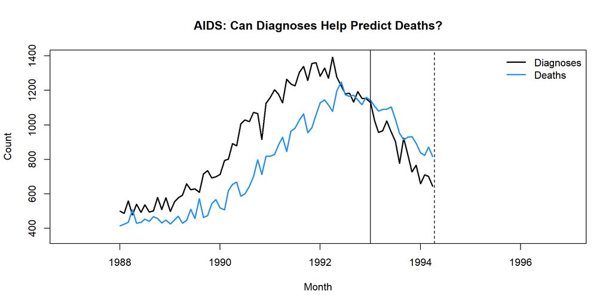

```r
# Load or generate AIDS data
# If you have real data, use: tmp3 <- readRDS("../data/aids.RDS")
# Otherwise, use synthetic data:
tmp3 <- generate_aids_data()

tmp <- aggregate(list(death = tmp3$deaths, diag = tmp3$diag),
                 list(month = tmp3$month), sum, na.rm = TRUE)
tmp$death <- ifelse(tmp$death == 0, NA, tmp$death)
tmp$diag <- ifelse(tmp$diag == 0, NA, tmp$diag)
tmp <- tmp[year(tmp$month) >= 1987,]

lim1 <- tmp$month <= ymd("1994-04-01") & !is.na(tmp$death)

plot(tmp$month, tmp$diag, type = "n",
     xlab = "Month", ylab = "Count",
     main = "AIDS: Can Diagnoses Help Predict Deaths?")
lines(tmp$month[lim1], tmp$diag[lim1], col = "black", lwd = 2)
lines(tmp$month[lim1], tmp$death[lim1], col = "dodgerblue", lwd = 2)
abline(v = ymd(c("1993-01-01", "1994-04-15")), lty = c(1, 2))
legend("topright", bty = "n", col = c("black", "dodgerblue"), lty = 1,
       legend = c("Diagnoses", "Deaths"), lwd = 2)
```

## Benchmark Model

Naive ARIMA forecast (no diagnoses information):

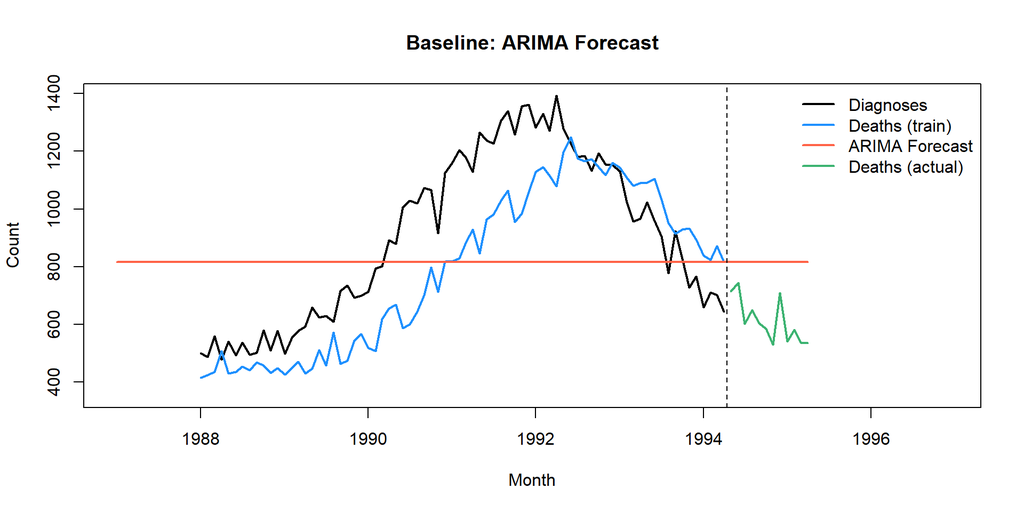

## Your Assignment

**Objective**: Beat the ARIMA benchmark using diagnoses as a leading indicator

## Hints for Success

1. **Explore the relationship**
   - Plot diagnoses vs deaths with different lags
   - What lag makes sense medically?
2. **Model choices**
   - `dynlm`: Easier for exploration, works with `stargazer`
   - `dLagM`: Has `forecast()` function for prediction
3. **Don’t overfit!**
   - More lags ≠ better forecast
   - Use AIC, but validate on holdout
4. **Code template available**
   - Commented starter code in slides
   - Shows data loading and ARIMA benchmark

## Starter Code Reminder

```r
# Load and prepare data
library("lubridate"); library("forecast"); library("tseries")

# If you have real data, use: tmp3 <- readRDS("../data/aids.RDS")
# Otherwise, use the synthetic data generator from the slides:
tmp3 <- generate_aids_data()

tmp <- aggregate(list(death = tmp3$deaths, diag = tmp3$diag),
                 list(month = tmp3$month), sum, na.rm = TRUE)
tmp$death <- ifelse(tmp$death == 0, NA, tmp$death)
tmp$diag <- ifelse(tmp$diag == 0, NA, tmp$diag)
tmp <- tmp[year(tmp$month) >= 1987,]

# Split train/test
lim1 <- tmp$month <= ymd("1994-04-01") & !is.na(tmp$death)
aids_ts <- ts(tmp[lim1, 2:3], start = c(1987), frequency = 12)

# TODO: Your model here (beat the ARIMA!)
# Hint: Use L(diag, k) for lagged diagnoses

# Benchmark ARIMA
reg1 <- auto.arima(aids_ts[,"death"])
p1 <- predict(reg1, n.ahead = 24)
```

## Next Class

**Week 12 (11/23)**: No Class - Thanksgiving Break

**Week 13 (11/30)**:

- Vector Autoregression (VAR)
- Impulse Response Functions
- Spatial Autocorrelation

**Week 14 (12/7)**:

- Final Project Presentations